# Moneyball vs. Millionaires: Examining the Need for a Salary Cap in Major League Baseball

Thomas Sigall

2023-12-06

# Introduction

### The 2002 Oakland Athletics

The legendary 2011 film “Moneyball” tells the story of the 2002 Oakland Athletics, a team taken over by general manager Billy Beane who led them to a historic season, winning 103 games, winning their division, and making the playoffs. The reason that season was immortalized into a movie, however, was not simply because the team had a historically good season. The 2002 Oakland Athletics did something far more remarkable. They were not just able to win, but they did it as a small market team, with an incredibly low payroll, the third lowest in the league in 2002 (Retrosheet 2002).

The Athletics had seen periods of success in their franchise’s history, but struggled to end the 1990’s. The problems they faced during that time were not unique to the Athletics. Many teams around the league were struggling because they could not keep up with the “big guys”. The Athletics were and are considered a “small market” team. This means they are located in an area with a lower population, meaning they bring in less money as an organization, meaning they have less money to spend on good players. They simply could not keep up with “large market” teams like the Yankees and Red Sox, teams with far deeper pockets. In 2002 alone, the New York Yankees spent $125 million on player salaries, the Boston Red Sox spend $108 million, and the Athletics spend a measly $40 million (Retrosheet 2002). In fact, many players would start with the Athletics and other small market teams, improve and become better ballplayers, then leave to the large market teams who could afford to pay them far more, essentially outbidding the smaller market teams.

The 2002 Oakland Athletics are a remarkable team because they were able to innovate and find value in players that did not cost nearly as much as the superstars New York and Boston were paying for. This was 20 years ago though, and now all teams use similar methods that were pioneered in that 2002 season. There is little value left to find out there on the smaller payrolls that these smaller market teams are given. This project is not about attempting to replicate what the 2002 Athletics were able to do. Instead, we will look at the system that forced them and all other small market teams to do more with less just to compete with large market teams. We will investigate the relationship between payroll and team success.

### The Competitive Balance Tax

To help decrease the gap between teams with deep pockets and teams without, most sports leagues in the United States have what is called a salary cap. This is as it sounds, an agreed upon limit on the amount teams can spend on player salaries. For example, the National Football league set its salary cap at $224,800,000 for the 2023 season (OverTheCap 2023). Teams are not permitted to spend more than that amount on their players and spend a lot of time trying to maneuver contracts to stay under that figure. Player salaries are by far the largest expense any team has and this hard limit on that expense helps to balance the playing field and close the gap between large market and small market teams.

The MLB, however, does not have a salary cap. There is no limit on the amount of money teams can spend on player salaries. Instead, they have implemented a system called the “Competitive Balance Tax” (CBT) (“MLB’s Evolving Luxury Tax — Blogs.fangraphs.com”). An amount is agreed upon by the league, the CBT threshold, though teams are allowed to exceed this amount in their payroll. If they do exceed this amount, they are taxed at a rate proportional to the number of years they have been over this amount. This system has been in place since 2002 and the values for the CBT threshold over the years are as follows (in millions of dollars):

| year | cbt | year | cbt | year | cbt | year | cbt |
| --- | --- | --- | --- | --- | --- | --- | --- |
| 2003 | $117.00 | 2008 | $155.00 | 2013 | $178.00 | 2018 | $197.00 |
| 2004 | $120.50 | 2009 | $162.00 | 2014 | $189.00 | 2019 | $206.00 |
| 2005 | $128.00 | 2010 | $170.00 | 2015 | $189.00 | 2020 | $208.00 |
| 2006 | $136.50 | 2011 | $178.00 | 2016 | $189.00 | 2021 | $210.00 |
| 2007 | $148.00 | 2012 | $178.00 | 2017 | $195.00 | 2022 | $230.00 |

Naturally, this value usually increases each year to keep up with various factors, such as inflation, increasing league revenues, and others. It is a fairly high value, as most teams have never passed this threshold in the 20 years of its existence. Enough teams do pass it, though, that it gives a good baseline to determine which teams are large market teams that spend big and which teams are not.

The theory behind this threshold is that it should punish wealthier teams for spending large amounts of money that smaller teams do not have. This should level the playing field and allow teams to spend similar amounts of money and encourage on-field competition as the way to determine the best team, rather than the league being a competition decided on who has the deepest pockets.

## Objectives

Now that the system the MLB has put in place is understood, we can look at the objectives of this project. The overall question that will be looked at is as follows:

> Does the MLB need a traditional salary cap?

- Do teams above the competitive balance tax threshold win more games than teams that are not?
- Is there a relationship between playoff teams and teams that are above the CBT threshold?
- Do teams in large population centers win more games than teams in small population centers?

There is some concern that a salary cap would do little to address the real issue, that teams in big cities will just always have more money than teams in small cities. There are more people in New York than Oakland, so it may be the case that Oakland is just in a smaller market and no salary cap will ever fix that. However, if spending is more indicative of team success than city population, we will have evidence that spending is what needs to be limited rather than population. This would be an encouraging sign as the MLB has far more control over how much teams spend than population growth in its cities.

# Data

## Tables

Data was gathered from many sources. First payroll data was obtained from Retrosheet (Retrosheet 2002) and formatted into a single table to be used for exploratory data analysis. This table includes team, season, payroll (in millions of dollars), winning percentage, if the team made the playoffs, and if the team is above the CBT. Playoff data is from Baseball Reference (“Baseball Reference” 2023).

| team | year | payroll | wpct | playoffs | above_cbt |
| --- | --- | --- | --- | --- | --- |
| Los Angeles Dodgers | 2022 | $285.51 | 0.685 | 1 | 1 |
| New York Mets | 2022 | $255.92 | 0.623 | 1 | 1 |
| New York Yankees | 2022 | $240.29 | 0.611 | 1 | 1 |
| Philadelphia Phillies | 2022 | $221.74 | 0.537 | 1 | 0 |
| San Diego Padres | 2022 | $202.17 | 0.549 | 1 | 0 |
| Boston Red Sox | 2022 | $201.62 | 0.481 | 0 | 0 |

In addition, population data was needed to address the concerns about population being a better predictor than payroll as explained earlier. Population data was obtained from the US Census Bureau (Bureau) and from the UN for Toronto’s population (“World Population Prospects 2022” 2022).

| City | Year | Population |
| --- | --- | --- |
| Atlanta city, Georgia | 2003 | 403080 |
| Atlanta city, Georgia | 2004 | 397365 |
| Atlanta city, Georgia | 2005 | 396311 |
| Atlanta city, Georgia | 2006 | 403548 |
| Atlanta city, Georgia | 2007 | 410086 |
| Atlanta city, Georgia | 2008 | 414233 |

The main population center was determined for each team and can be seen in the appendix. Note that some population centers have multiple teams.

## Exploratory Data Analysis

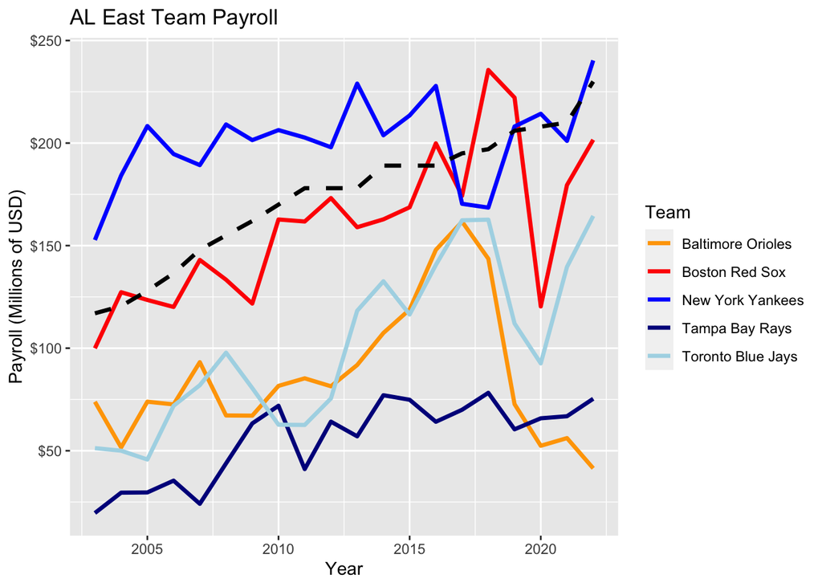

# Appendix

| team | cities |
| --- | --- |
| Arizona Diamondbacks | Phoenix city, Arizona |
| Atlanta Braves | Atlanta city, Georgia |
| Baltimore Orioles | Baltimore city, Maryland |
| Boston Red Sox | Boston city, Massachusetts |
| Chicago Cubs | Chicago city, Illinois |
| Chicago White Sox | Chicago city, Illinois |
| Cincinnati Reds | Cincinnati city, Ohio |
| Cleveland Guardians | Cleveland city, Ohio |
| Colorado Rockies | Denver city, Colorado |
| Detroit Tigers | Detroit city, Michigan |
| Houston Astros | Houston city, Texas |
| Kansas City Royals | Kansas City city, Missouri |
| Los Angeles Angels | Los Angeles city, California |
| Los Angeles Dodgers | Los Angeles city, California |
| Miami Marlins | Miami city, Florida |
| Milwaukee Brewers | Milwaukee city, Wisconsin |
| Minnesota Twins | Minneapolis city, Minnesota |
| New York Mets | New York city, New York |
| New York Yankees | New York city, New York |
| Oakland Athletics | Oakland city, California |
| Philadelphia Phillies | Philadelphia city, Pennsylvania |
| Pittsburgh Pirates | Pittsburgh city, Pennsylvania |
| San Diego Padres | San Diego city, California |
| San Francisco Giants | San Francisco city, California |
| Seattle Mariners | Seattle city, Washington |
| St. Louis Cardinals | St. Louis city, Missouri |
| Tampa Bay Rays | Tampa city, Florida |
| Texas Rangers | Dallas city, Texas |
| Toronto Blue Jays | Toronto |
| Washington Nationals | Washington city, District of Columbia |

# References

“Baseball Reference.” 2023. https://www.baseball-reference.com/teams/.

Bureau, US Census. “City and Town Population Totals: 2020-2022 — Census.gov.” https://www.census.gov/data/tables/time-series/demo/popest/2020s-total-cities-and-towns.html.

“MLB’s Evolving Luxury Tax — Blogs.fangraphs.com.” https://blogs.fangraphs.com/mlbs-evolving-luxury-tax/.

OverTheCap. 2023. “Salary Cap Space.” https://overthecap.com/salary-cap-space.

Retrosheet. 2002. “2002 Payroll.” https://www.thebaseballcube.com/page.asp?PT=payroll_year&ID=2002.

“World Population Prospects 2022.” 2022. https://population.un.org/wpp/.